# CodeBook for MSDS6306 - Case Study 2

Lavonnia Newman, Jeff Washburn, & Joseph Caguioa

2/25/2019

# Data report overview

The dataset examined has the following dimensions:

| Feature | Result |
| --- | --- |
| Number of observations | 1470 |
| Number of variables | 35 |

# **Codebook Summary Table**

## employee

| Original Unedited Names | Variable | Class values | # unique | Missing |
| --- | --- | --- | --- | --- |
| Age | **Age** | numeric | 43 | 0.00 % |
| Attrition | **Attrition** | character | 2 | 0.00 % |
| BusinessTravel | **BusTravel** | character | 3 | 0.00 % |
| DailyRate | **DailyRate** | numeric | 886 | 0.00 % |
| Department | **Department** | character | 3 | 0.00 % |
| DistranceFromHOme | **DistFromHme** | numeric | 29 | 0.00 % |
| Education | **Education** | numeric | 5 | 0.00 % |
| EducationField | **EduField** | character | 6 | 0.00 % |
| EmployeeCount | **EmpCount** | numeric | 1 | 0.00 % |
| EmployeeNumber | **EmpId** | numeric | 1470 | 0.00 % |
| EnvironmentSatisfaction | **EnvironSat** | numeric | 4 | 0.00 % |
| Gender | **Gender** | character | 2 | 0.00 % |
| HourlyRate | **HourlyRate** | numeric | 71 | 0.00 % |
| JobInvolvement | **JobInvolvemt** | numeric | 4 | 0.00 % |
| JobLevel | **JobLevel** | numeric | 5 | 0.00 % |
| JobRole | **JobRole** | character | 9 | 0.00 % |
| JObSatisfaction | **JobSat** | numeric | 4 | 0.00 % |
| MaritalStatus | **MaritalStat** | character | 3 | 0.00 % |
| MonnthlyIncome | **MnthInc** | numeric | 1349 | 0.00 % |
| MonthlyRate | **MnthRate** | numeric | 1427 | 0.00 % |
| NumCompaniesWorked | **NumCoWorked** | numeric | 10 | 0.00 % |
| Over18 | **Over18** | character | 1 | 0.00 % |
| Overtime | **Overtime** | character | 2 | 0.00 % |
| PercentSalaryHike | **PcntSalInc** | numeric | 15 | 0.00 % |
| PerformanceRating | **PerfRating** | numeric | 2 | 0.00 % |
| RelationshipSatisfaction | **RelationSat** | numeric | 4 | 0.00 % |
| StandardHours | **StandHours** | numeric | 1 | 0.00 % |
| StockOptionLevel | **StckOptLev** | numeric | 4 | 0.00 % |
| TotalWorkingYears | **TotalWrkYrs** | numeric | 40 | 0.00 % |
| TrainingTimesLastYear | **TrainPrevYr** | numeric | 7 | 0.00 % |
| WorkLifeBalance | **WorkLifeBal** | numeric | 4 | 0.00 % |
| YearsAtCompany | **YrsAtComp** | numeric | 37 | 0.00 % |
| YearsInCurrentRole | **YrsCurrRole** | numeric | 19 | 0.00 % |
| YearsSinceLastPromotion | **YrsSncPromo** | numeric | 16 | 0.00 % |
| YearsWithCurrManager | **YrsWtCurMgr** | numeric | 18 | 0.00 % |

## **Variable list**

### Age

| Feature | Result |
| --- | --- |
| Variable type | numeric |
| Number of missing obs. | 0 (0 %) |
| Number of unique values | 43 |
| Median | 36 |
| 1st and 3rd quartiles | 30; 43 |
| Min. and max. | 18; 60 |

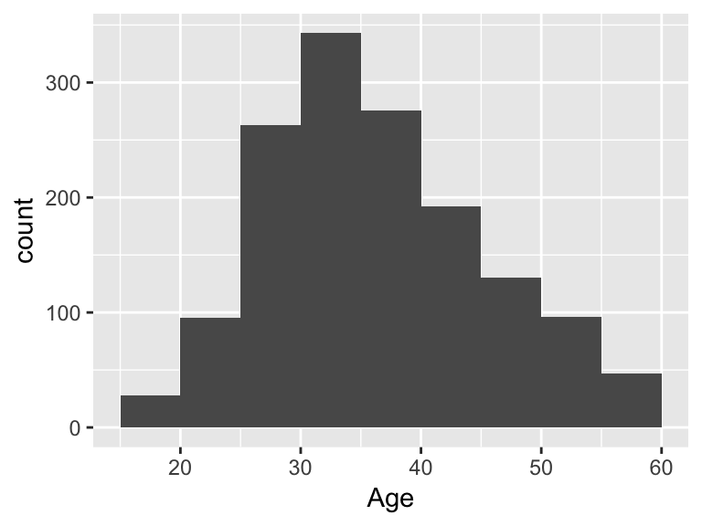

### Attrition

| Feature | Result |
| --- | --- |
| Variable type | character |
| Number of missing obs. | 0 (0 %) |
| Number of unique values | 2 |
| Mode | “No” |

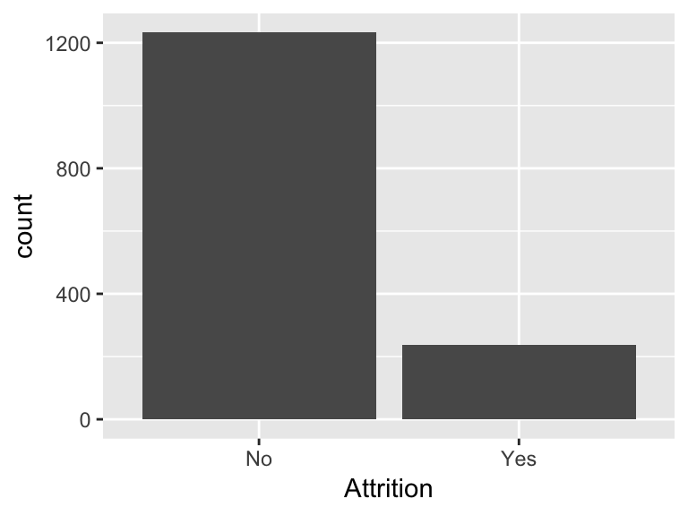

- Observed factor levels: "No", "Yes".

### BusTravel

| Feature | Result |
| --- | --- |
| Variable type | character |
| Number of missing obs. | 0 (0 %) |
| Number of unique values | 3 |
| Mode | “Travel_Rarely” |

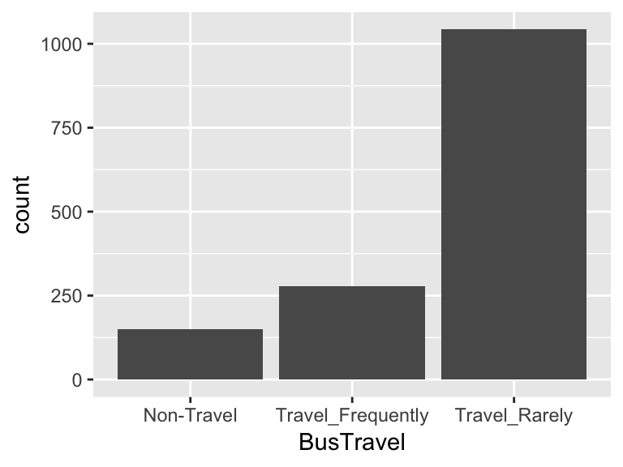

- Observed factor levels: "Non-Travel", "Travel_Frequently", "Travel_Rarely".

### DailyRate

| Feature | Result |
| --- | --- |
| Variable type | numeric |
| Number of missing obs. | 0 (0 %) |
| Number of unique values | 886 |
| Median | 802 |
| 1st and 3rd quartiles | 465; 1157 |
| Min. and max. | 102; 1499 |

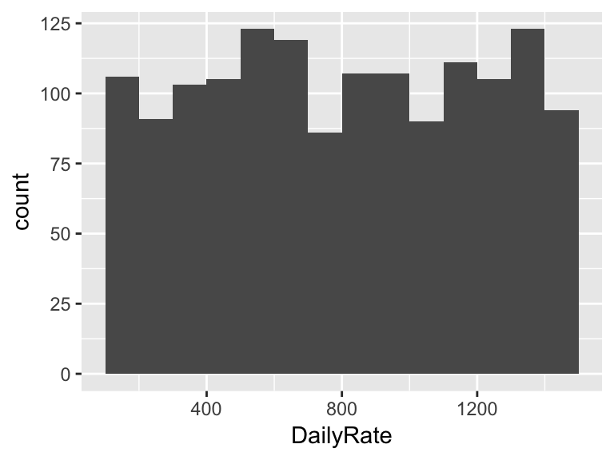

### Department

| Feature | Result |
| --- | --- |
| Variable type | character |
| Number of missing obs. | 0 (0 %) |
| Number of unique values | 3 |
| Mode | “Research & Development” |

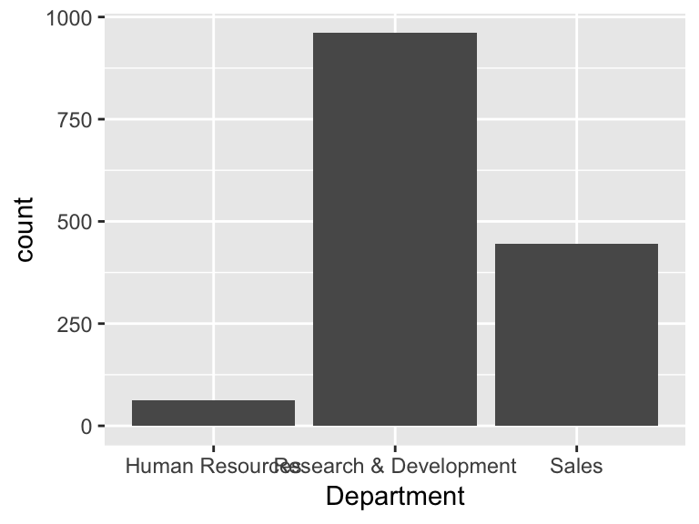

- Observed factor levels: "Human Resources", "Research & Development", "Sales".

### DistFromHme

| Feature | Result |
| --- | --- |
| Variable type | numeric |
| Number of missing obs. | 0 (0 %) |
| Number of unique values | 29 |
| Median | 7 |
| 1st and 3rd quartiles | 2; 14 |
| Min. and max. | 1; 29 |

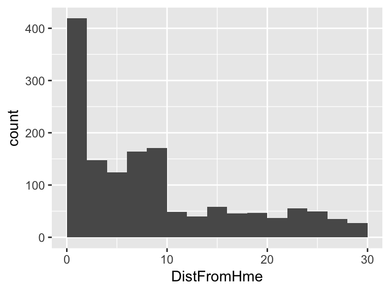

### Education

| Feature | Result |
| --- | --- |
| Variable type | numeric |
| Number of missing obs. | 0 (0 %) |
| Number of unique values | 5 |
| Median | 3 |
| 1st and 3rd quartiles | 2; 4 |
| Min. and max. | 1; 5 |

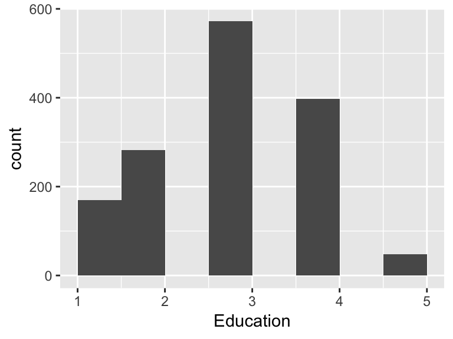

### EduField

| Feature | Result |
| --- | --- |
| Variable type | character |
| Number of missing obs. | 0 (0 %) |
| Number of unique values | 6 |
| Mode | “Life Sciences” |

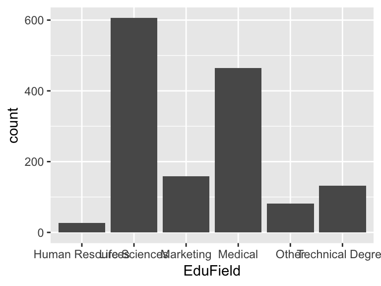

- Observed factor levels: "Human Resources", "Life Sciences", "Marketing", "Medical", "Other", "Technical Degree".

### EmpCount

- The variable only takes one (non-missing) value: "1". The variable contains 0 % missing observations.

### EmpId

| Feature | Result |
| --- | --- |
| Variable type | numeric |
| Number of missing obs. | 0 (0 %) |
| Number of unique values | 1470 |
| Median | 1020.5 |
| 1st and 3rd quartiles | 491.25; 1555.75 |
| Min. and max. | 1; 2068 |

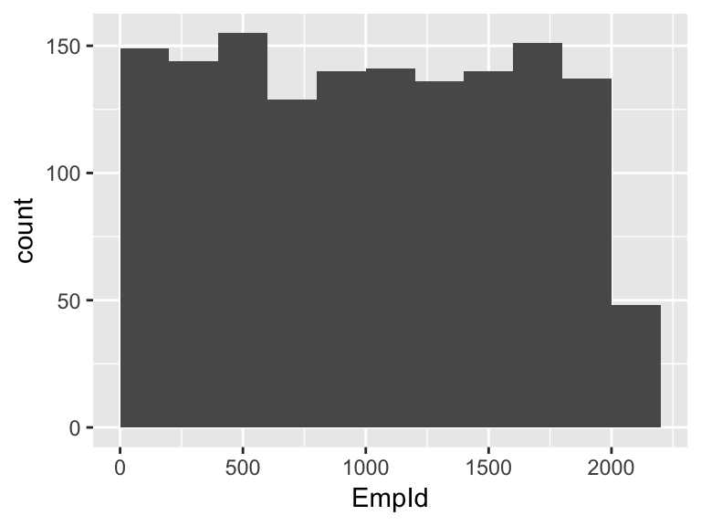

### EnvironSat

| Feature | Result |
| --- | --- |
| Variable type | numeric |
| Number of missing obs. | 0 (0 %) |
| Number of unique values | 4 |
| Median | 3 |
| 1st and 3rd quartiles | 2; 4 |
| Min. and max. | 1; 4 |

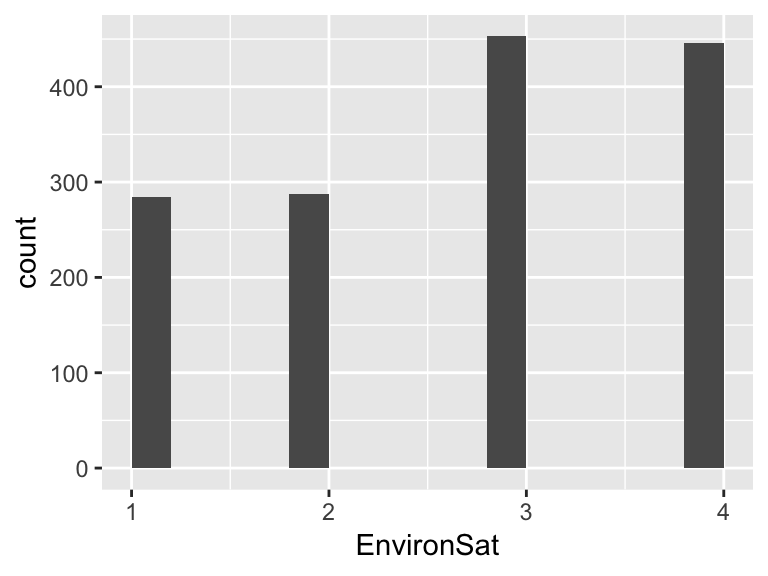

### Gender

| Feature | Result |
| --- | --- |
| Variable type | character |
| Number of missing obs. | 0 (0 %) |
| Number of unique values | 2 |
| Mode | “Male” |

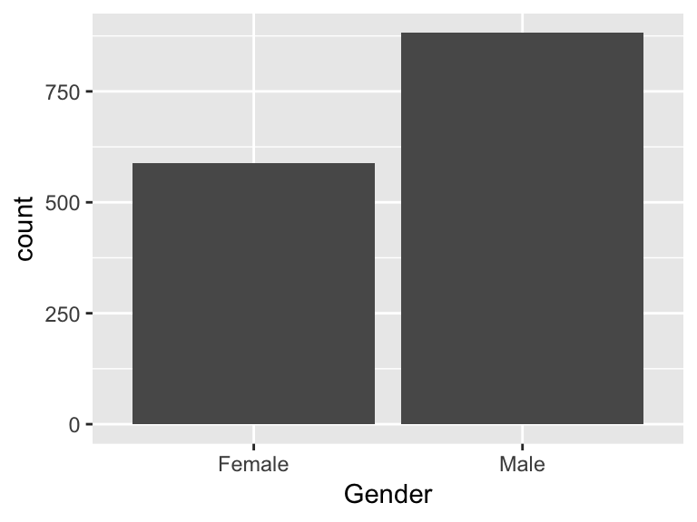

- Observed factor levels: "Female", "Male".

### HourlyRate

| Feature | Result |
| --- | --- |
| Variable type | numeric |
| Number of missing obs. | 0 (0 %) |
| Number of unique values | 71 |
| Median | 66 |
| 1st and 3rd quartiles | 48; 83.75 |
| Min. and max. | 30; 100 |

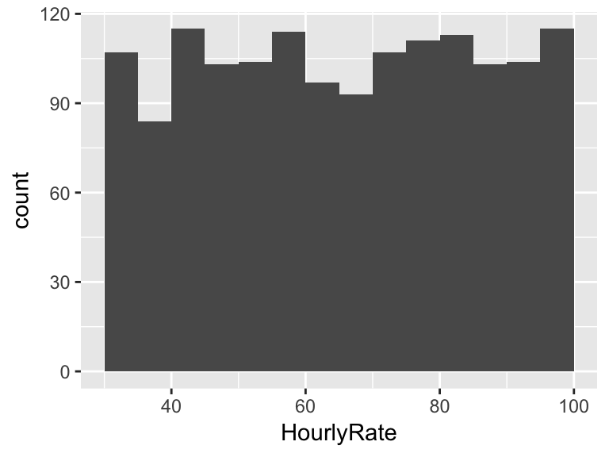

### JobInvolvemt

| Feature | Result |
| --- | --- |
| Variable type | numeric |
| Number of missing obs. | 0 (0 %) |
| Number of unique values | 4 |
| Median | 3 |
| 1st and 3rd quartiles | 2; 3 |
| Min. and max. | 1; 4 |

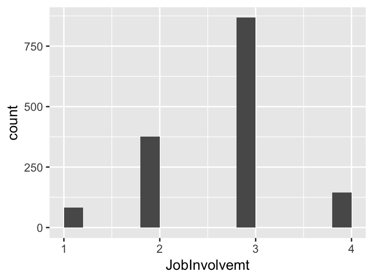

### JobLevel

| Feature | Result |
| --- | --- |
| Variable type | numeric |
| Number of missing obs. | 0 (0 %) |
| Number of unique values | 5 |
| Median | 2 |
| 1st and 3rd quartiles | 1; 3 |
| Min. and max. | 1; 5 |

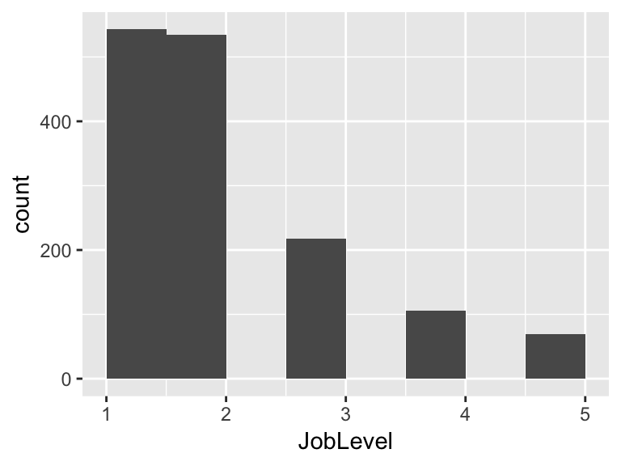

### JobRole

| Feature | Result |
| --- | --- |
| Variable type | character |
| Number of missing obs. | 0 (0 %) |
| Number of unique values | 9 |
| Mode | “Sales Executive” |

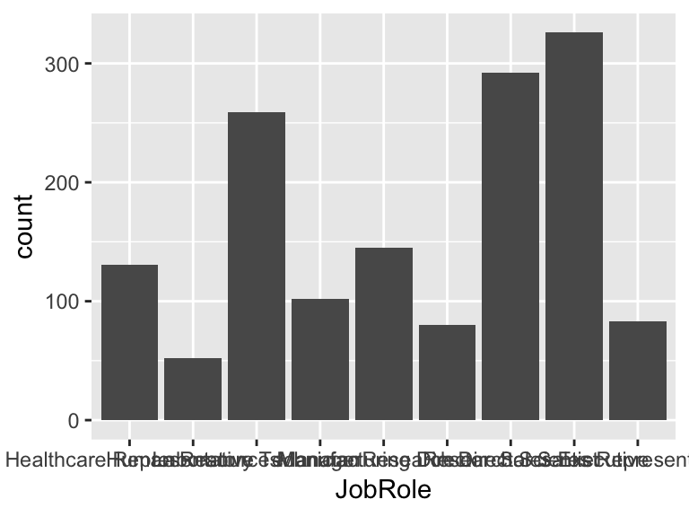

- Observed factor levels: "Healthcare Representative", "Human Resources", "Laboratory Technician", "Manager", "Manufacturing Director", "Research Director", "Research Scientist", "Sales Executive", "Sales Representative".

### JobSat

| Feature | Result |
| --- | --- |
| Variable type | numeric |
| Number of missing obs. | 0 (0 %) |
| Number of unique values | 4 |
| Median | 3 |
| 1st and 3rd quartiles | 2; 4 |
| Min. and max. | 1; 4 |

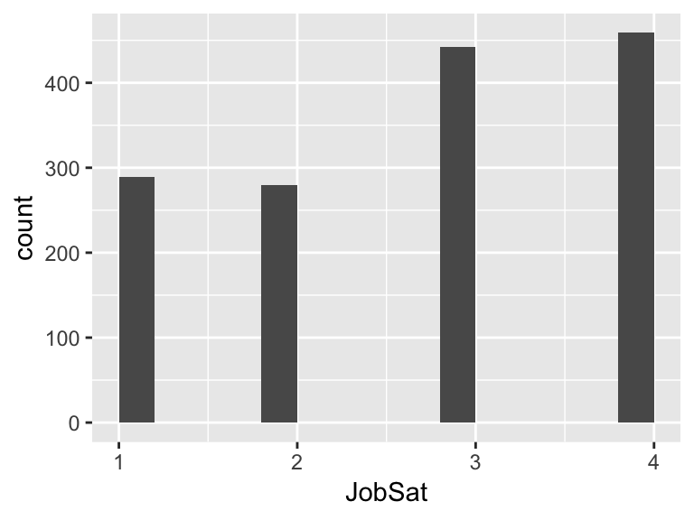

### MaritalStat

| Feature | Result |
| --- | --- |
| Variable type | character |
| Number of missing obs. | 0 (0 %) |
| Number of unique values | 3 |
| Mode | “Married” |

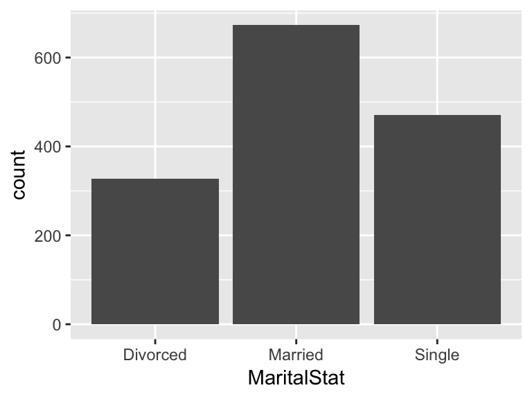

- Observed factor levels: "Divorced", "Married", "Single".

### MnthInc

| Feature | Result |
| --- | --- |
| Variable type | numeric |
| Number of missing obs. | 0 (0 %) |
| Number of unique values | 1349 |
| Median | 4919 |
| 1st and 3rd quartiles | 2911; 8379 |
| Min. and max. | 1009; 19999 |

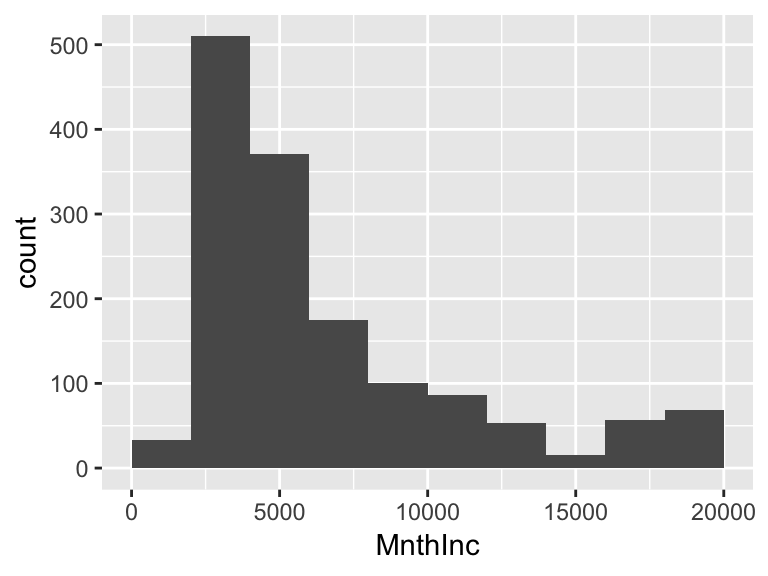

### MnthRate

| Feature | Result |
| --- | --- |
| Variable type | numeric |
| Number of missing obs. | 0 (0 %) |
| Number of unique values | 1427 |
| Median | 14235.5 |
| 1st and 3rd quartiles | 8047; 20461.5 |
| Min. and max. | 2094; 26999 |

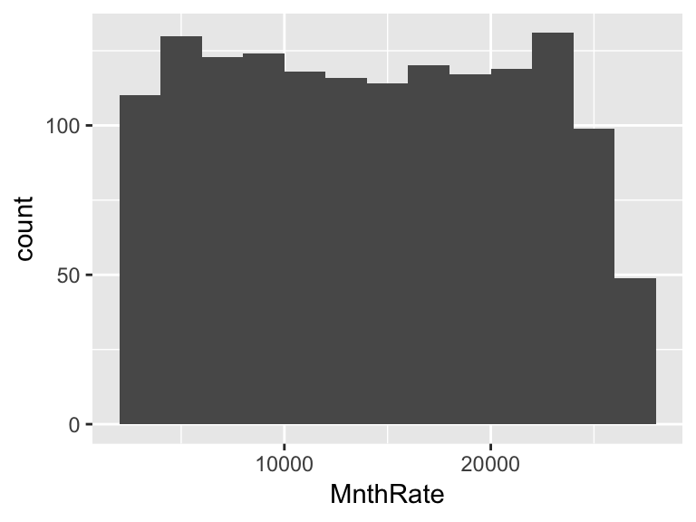

### NumCoWorked

| Feature | Result |
| --- | --- |
| Variable type | numeric |
| Number of missing obs. | 0 (0 %) |
| Number of unique values | 10 |
| Median | 2 |
| 1st and 3rd quartiles | 1; 4 |
| Min. and max. | 0; 9 |

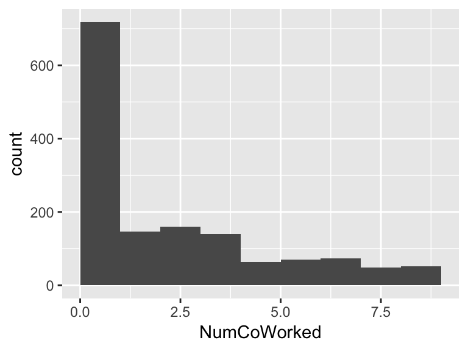

### Over18

- The variable only takes one (non-missing) value: "Y". The variable contains 0 % missing observations.

### Overtime

| Feature | Result |
| --- | --- |
| Variable type | character |
| Number of missing obs. | 0 (0 %) |
| Number of unique values | 2 |
| Mode | “No” |

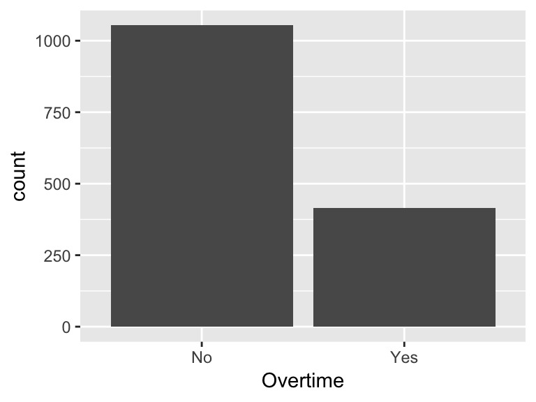

- Observed factor levels: "No", "Yes".

### PcntSalInc

| Feature | Result |
| --- | --- |
| Variable type | numeric |
| Number of missing obs. | 0 (0 %) |
| Number of unique values | 15 |
| Median | 14 |
| 1st and 3rd quartiles | 12; 18 |
| Min. and max. | 11; 25 |

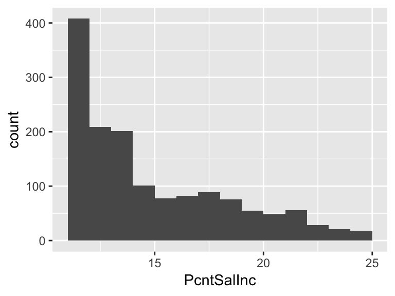

### PerfRating

| Feature | Result |
| --- | --- |
| Variable type | numeric |
| Number of missing obs. | 0 (0 %) |
| Number of unique values | 2 |
| Median | 3 |
| 1st and 3rd quartiles | 3; 3 |
| Min. and max. | 3; 4 |

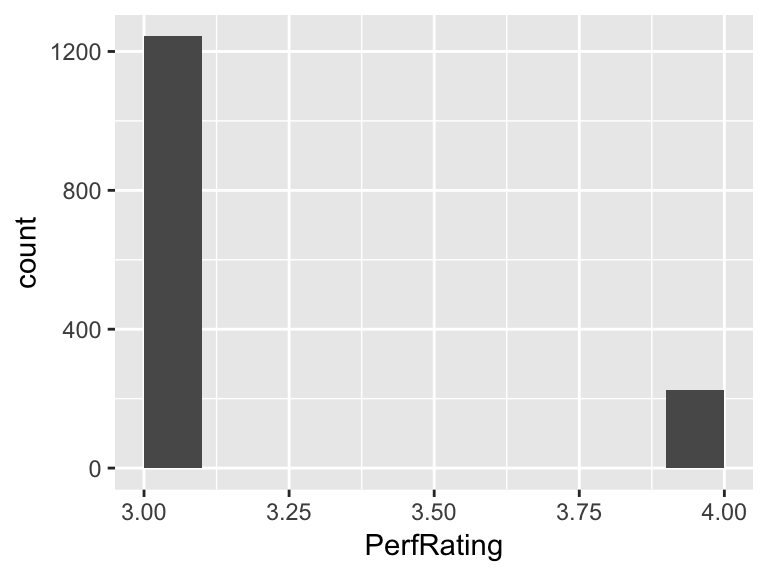

### RelationSat

| Feature | Result |
| --- | --- |
| Variable type | numeric |
| Number of missing obs. | 0 (0 %) |
| Number of unique values | 4 |
| Median | 3 |
| 1st and 3rd quartiles | 2; 4 |
| Min. and max. | 1; 4 |

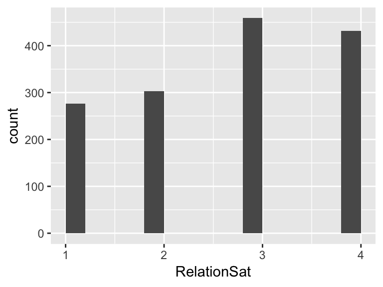

### StandHours

- The variable only takes one (non-missing) value: "80". The variable contains 0 % missing observations.

### StckOptLev

| Feature | Result |
| --- | --- |
| Variable type | numeric |
| Number of missing obs. | 0 (0 %) |
| Number of unique values | 4 |
| Median | 1 |
| 1st and 3rd quartiles | 0; 1 |
| Min. and max. | 0; 3 |

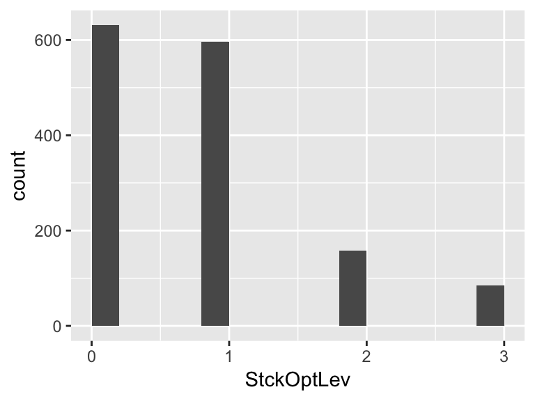

### TotalWrkYrs

| Feature | Result |
| --- | --- |
| Variable type | numeric |
| Number of missing obs. | 0 (0 %) |
| Number of unique values | 40 |
| Median | 10 |
| 1st and 3rd quartiles | 6; 15 |
| Min. and max. | 0; 40 |

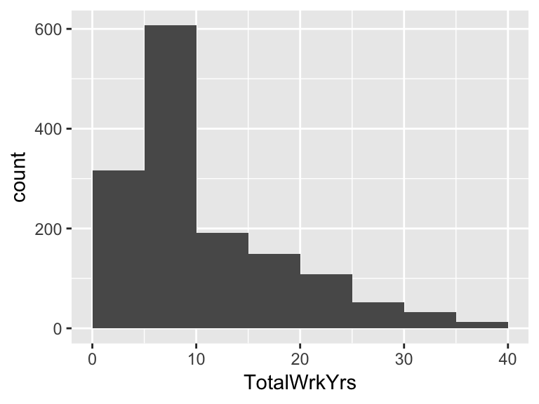

### TrainPrevYr

| Feature | Result |
| --- | --- |
| Variable type | numeric |
| Number of missing obs. | 0 (0 %) |
| Number of unique values | 7 |
| Median | 3 |
| 1st and 3rd quartiles | 2; 3 |
| Min. and max. | 0; 6 |

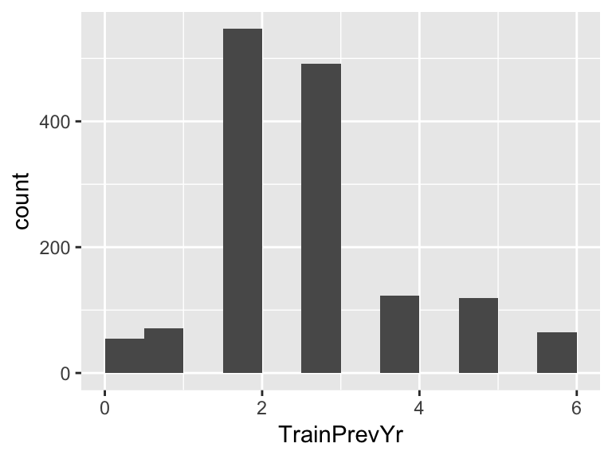

### WorkLifeBal

| Feature | Result |
| --- | --- |
| Variable type | numeric |
| Number of missing obs. | 0 (0 %) |
| Number of unique values | 4 |
| Median | 3 |
| 1st and 3rd quartiles | 2; 3 |
| Min. and max. | 1; 4 |

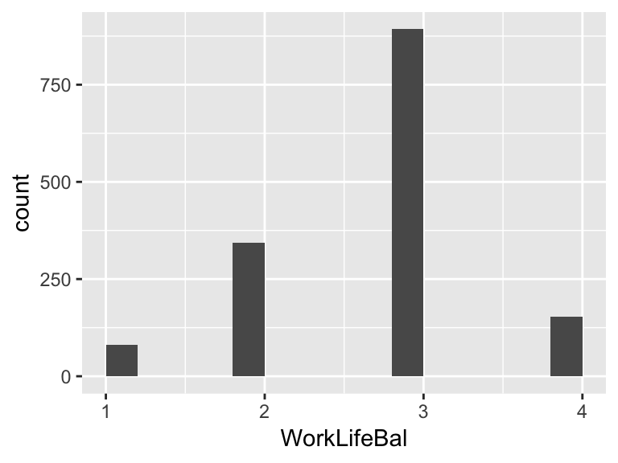

### YrsAtComp

| Feature | Result |
| --- | --- |
| Variable type | numeric |
| Number of missing obs. | 0 (0 %) |
| Number of unique values | 37 |
| Median | 5 |
| 1st and 3rd quartiles | 3; 9 |
| Min. and max. | 0; 40 |

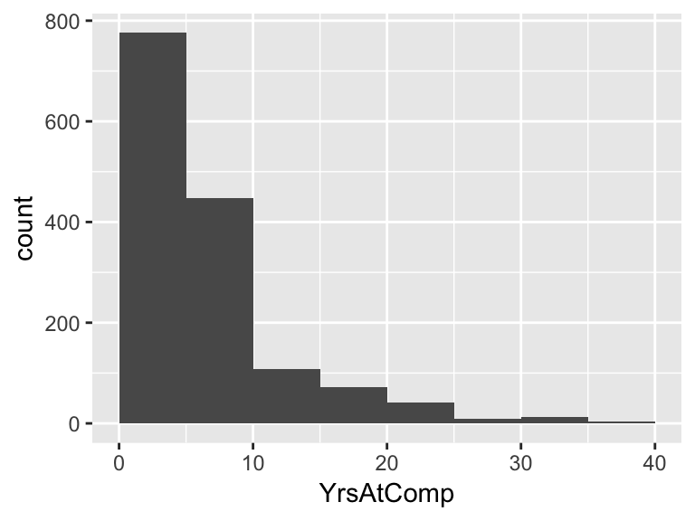

### YrsCurrRole

| Feature | Result |
| --- | --- |
| Variable type | numeric |
| Number of missing obs. | 0 (0 %) |
| Number of unique values | 19 |
| Median | 3 |
| 1st and 3rd quartiles | 2; 7 |
| Min. and max. | 0; 18 |

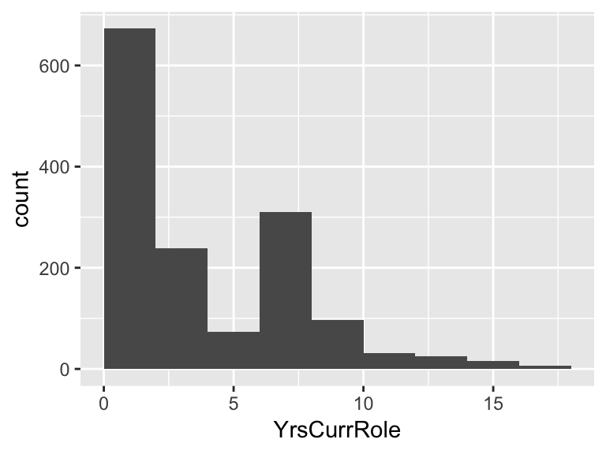

### YrsSncPromo

| Feature | Result |
| --- | --- |
| Variable type | numeric |
| Number of missing obs. | 0 (0 %) |
| Number of unique values | 16 |
| Median | 1 |
| 1st and 3rd quartiles | 0; 3 |
| Min. and max. | 0; 15 |

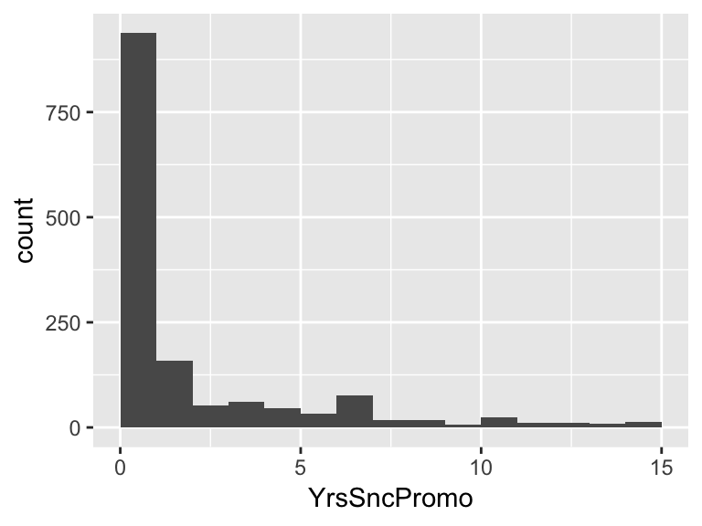

### YrsWtCurMgr

| Feature | Result |
| --- | --- |
| Variable type | numeric |
| Number of missing obs. | 0 (0 %) |
| Number of unique values | 18 |
| Median | 3 |
| 1st and 3rd quartiles | 2; 7 |
| Min. and max. | 0; 17 |

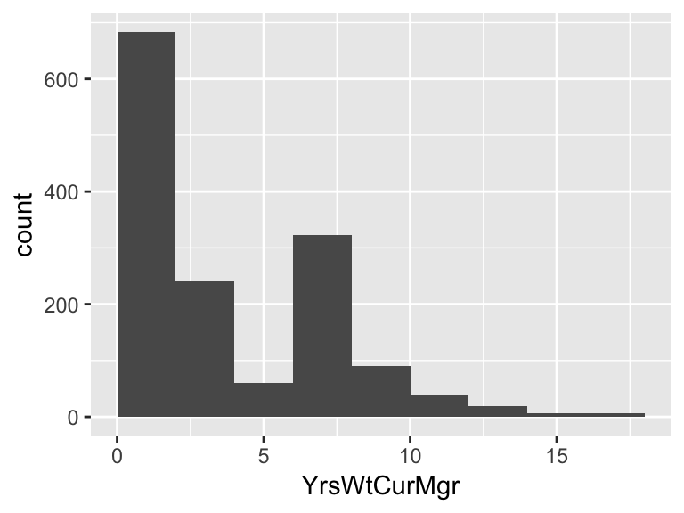

# **Analysis Objects**

Three versions of the original employee data frame are created. One converts all character variables and select rating-type numeric variables to factors. The second dataframe goes a step further and coerces all variables to numeric. The third version is the same as employee_factor with various fields having a log transformation. All are used in different ways during the analysis.

### employee_factor

| Variable | Class | # unique | Missing values |
| --- | --- | --- | --- |
| **Age** | numeric | 43 | 0.00 % |
| **Attrition** | factor | 2 | 0.00 % |
| **BusTravel** | factor | 3 | 0.00 % |
| **DailyRate** | numeric | 886 | 0.00 % |
| **Department** | factor | 3 | 0.00 % |
| **DistFromHme** | numeric | 29 | 0.00 % |
| **Education** | factor | 5 | 0.00 % |
| **EduField** | factor | 6 | 0.00 % |
| **EmpCount** | numeric | 1 | 0.00 % |
| **EmpId** | numeric | 1470 | 0.00 % |
| **EnvironSat** | factor | 4 | 0.00 % |
| **Gender** | factor | 2 | 0.00 % |
| **HourlyRate** | numeric | 71 | 0.00 % |
| **JobInvolvemt** | factor | 4 | 0.00 % |
| **JobLevel** | factor | 5 | 0.00 % |
| **JobRole** | factor | 9 | 0.00 % |
| **JobSat** | factor | 4 | 0.00 % |
| **MaritalStat** | factor | 3 | 0.00 % |
| **MnthInc** | numeric | 1349 | 0.00 % |
| **MnthRate** | numeric | 1427 | 0.00 % |
| **NumCoWorked** | numeric | 10 | 0.00 % |
| **Over18** | factor | 1 | 0.00 % |
| **Overtime** | factor | 2 | 0.00 % |
| **PcntSalInc** | numeric | 15 | 0.00 % |
| **PerfRating** | factor | 2 | 0.00 % |
| **RelationSat** | factor | 4 | 0.00 % |
| **StandHours** | factor | 1 | 0.00 % |
| **StckOptLev** | factor | 4 | 0.00 % |
| **TotalWrkYrs** | numeric | 40 | 0.00 % |
| **TrainPrevYr** | numeric | 7 | 0.00 % |
| **WorkLifeBal** | factor | 4 | 0.00 % |
| **YrsAtComp** | numeric | 37 | 0.00 % |
| **YrsCurrRole** | numeric | 19 | 0.00 % |
| **YrsSncPromo** | numeric | 16 | 0.00 % |
| **YrsWtCurMgr** | numeric | 18 | 0.00 % |

### employee_numeric

| Variable | Class | # unique | Missing values |
| --- | --- | --- | --- |
| **Age** | numeric | 43 | 0.00 % |
| **Attrition** | numeric | 2 | 0.00 % |
| **BusTravel** | numeric | 3 | 0.00 % |
| **DailyRate** | numeric | 886 | 0.00 % |
| **Department** | numeric | 3 | 0.00 % |
| **DistFromHme** | numeric | 29 | 0.00 % |
| **Education** | numeric | 5 | 0.00 % |
| **EduField** | numeric | 6 | 0.00 % |
| **EmpCount** | numeric | 1 | 0.00 % |
| **EmpId** | numeric | 1470 | 0.00 % |
| **EnvironSat** | numeric | 4 | 0.00 % |
| **Gender** | numeric | 2 | 0.00 % |
| **HourlyRate** | numeric | 71 | 0.00 % |
| **JobInvolvemt** | numeric | 4 | 0.00 % |
| **JobLevel** | numeric | 5 | 0.00 % |
| **JobRole** | numeric | 9 | 0.00 % |
| **JobSat** | numeric | 4 | 0.00 % |
| **MaritalStat** | numeric | 3 | 0.00 % |
| **MnthInc** | numeric | 1349 | 0.00 % |
| **MnthRate** | numeric | 1427 | 0.00 % |
| **NumCoWorked** | numeric | 10 | 0.00 % |
| **Over18** | numeric | 1 | 0.00 % |
| **Overtime** | numeric | 2 | 0.00 % |
| **PcntSalInc** | numeric | 15 | 0.00 % |
| **PerfRating** | numeric | 2 | 0.00 % |
| **RelationSat** | numeric | 4 | 0.00 % |
| **StandHours** | numeric | 1 | 0.00 % |
| **StckOptLev** | numeric | 4 | 0.00 % |
| **TotalWrkYrs** | numeric | 40 | 0.00 % |
| **TrainPrevYr** | numeric | 7 | 0.00 % |
| **WorkLifeBal** | numeric | 4 | 0.00 % |
| **YrsAtComp** | numeric | 37 | 0.00 % |
| **YrsCurrRole** | numeric | 19 | 0.00 % |
| **YrsSncPromo** | numeric | 16 | 0.00 % |
| **YrsWtCurMgr** | numeric | 18 | 0.00 % |

### employee_log

[output not shown]

# Non-Visualization Variables

[output not shown]

# Visualization Variables

[output not shown]